# Deep Learning with Keras in R — Credit Card Default Prediction

## Payment Behavior Analysis

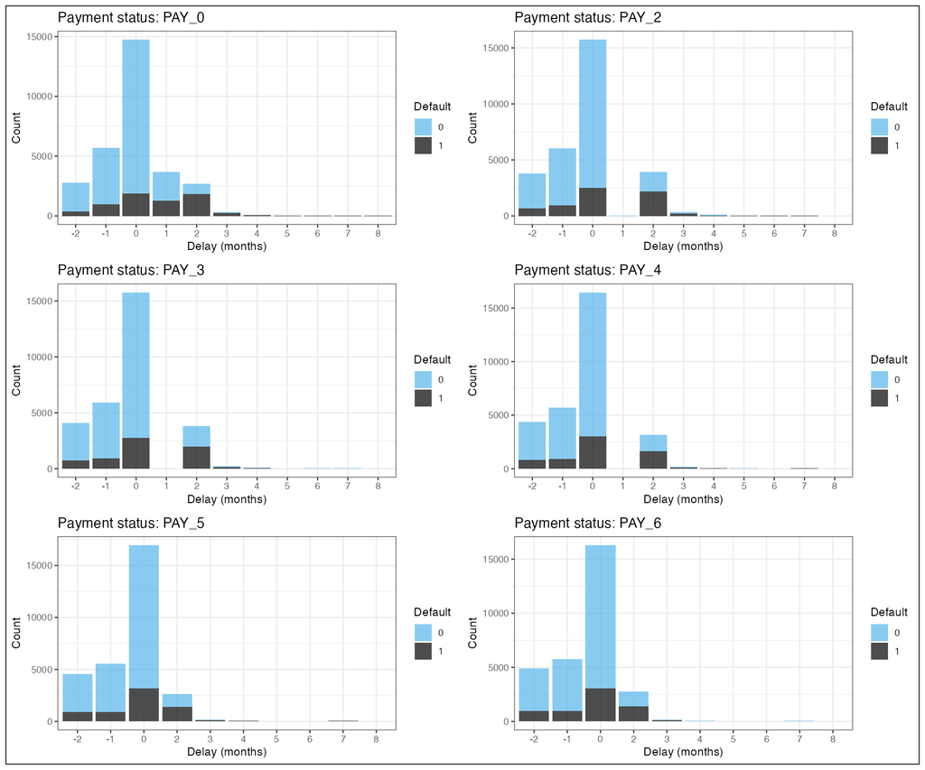

Payment Status Patterns Across 6 Months

**Payment Status Insights:** - Most customers pay on time (status 0) - Customers with payment delays (positive values) show higher default rates - The pattern is consistent across all 6 months, indicating payment behavior is a strong predictor - Customers with longer payment delays show exponentially higher default rates

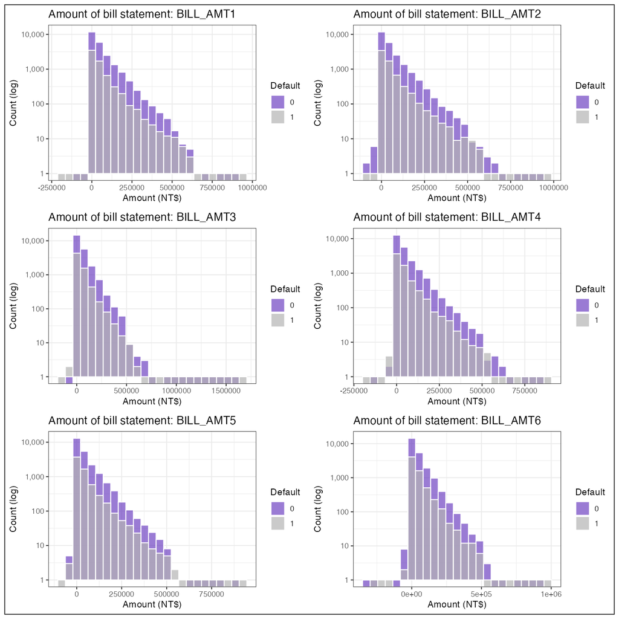

Bill Amount Distribution Across 6 Months

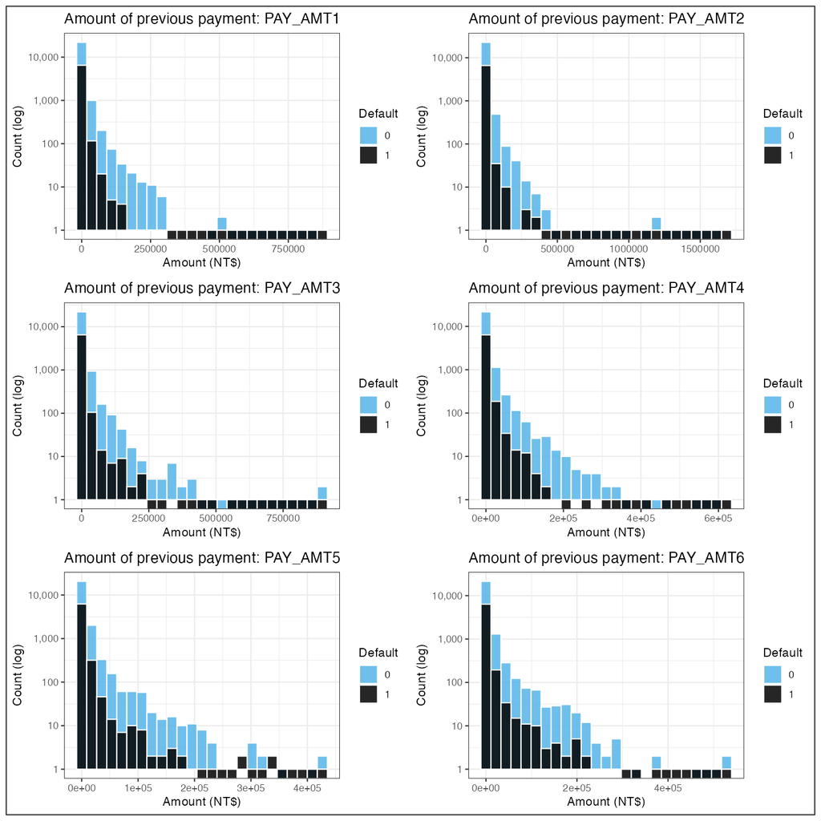

Previous Payment Amount Distribution Across 6 Months

**Payment Amount Insights:** - Payment amounts show similar patterns to bill amounts - Default cases tend to have lower payment amounts relative to bill amounts - The ratio of payment to bill amount is likely a strong predictor - Many customers make minimum payments or no payments